# Project7_NeualNetworks_BankChrun_Prediction

### Model 1 - Using SGD

```python
clear_backend()
```

```python
# Initializing the ANN
model = Sequential()
# The amount of nodes (dimensions) in hidden layer should be the average of input and output layers, in this case 64.
# This adds the input layer (by specifying input dimension) AND the first hidden layer (units)
model.add(Dense(activation = 'relu', input_dim = X_train.shape[1], units=64))
#Add 1st hidden layer
model.add(Dense(32, activation='relu'))
# Adding the output layer
# Notice that we do not need to specify input dim.
# we have an output of 1 node, which is the the desired dimensions of our output (stay with the bank or not)
# We use the sigmoid because we want probability outcomes
model.add(Dense(1, activation = 'sigmoid'))
```

```python
# Create optimizer with default learning rate
# Compile the model
model.compile(optimizer='SGD', loss='binary_crossentropy', metrics=['accuracy'])
```

```python
model.summary()
```

```
Model: "sequential"
_________________________________________________________________
 Layer (type)                Output Shape              Param #
=================================================================
 dense (Dense)               (None, 64)                832

 dense_1 (Dense)             (None, 32)                2080

 dense_2 (Dense)             (None, 1)                 33

=================================================================
Total params: 2,945
Trainable params: 2,945
Non-trainable params: 0
_________________________________________________________________
```

```python
history=model.fit(X_train, y_train,
          validation_split=0.2,
          epochs=50,
          batch_size=32,verbose=1)
```

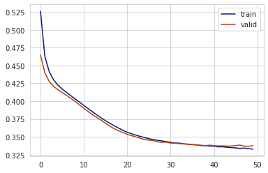

```python
plot_accuracy_forEPOCs(history,model,X_test,y_test)
```

Validation and training *Loss* is decreasing steadily after the 20th EPOCH, there is a sudden decline between 0th and 20th EPOCH, There is very minimal noise in the validation set. Sometimes, Loss function fluctuates a lot during training which makes the convergence slow. Sometimes Stochastic Gradient Descent produces noisy updates in the parameters.

Let's check other metrices.

```python
y_pred=model.predict(X_test)
y_pred = (y_pred > 0.5)
y_pred
```

```
array([[False],
       [False],
       [False],
       ...,
       [ True],
       [False],
       [False]])
```

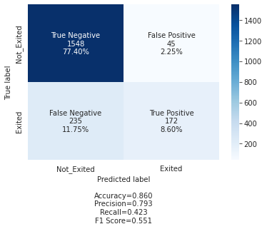

```python
create_confusionMatrix(y_test, y_pred)
```

```python
#Accuracy as per the classification report
cr=metrics.classification_report(y_test,y_pred)
print('Model Using SGD')
print(cr)
```

```
Model Using SGD
              precision    recall  f1-score   support

           0       0.87      0.97      0.92      1593
           1       0.79      0.42      0.55       407

    accuracy                           0.86      2000
   macro avg       0.83      0.70      0.73      2000
weighted avg       0.85      0.86      0.84      2000
```

1) **Imbalanced dataset**: As you have seen in the EDA, this dataset is imbalanced, and it contains more examples that belong to the **0** class.

2) **Decision Threshold**: Due to the imbalanced dataset, we can use ROC-AUC to find the optimal threshold and use the same for prediction.

Let's try to change the optimizer, tune the decision threshold, increase the layers and configure some other hyperparameters accordingly, in order to improve the model's performance.

### Model 2 - Using Adam optimizer

```python
clear_backend()
```

```python
model1 = Sequential()
#Adding the hidden and output layers
model1.add(Dense(256,activation='relu',kernel_initializer='he_uniform',input_dim = X_train.shape[1]))
model1.add(Dense(128,activation='relu',kernel_initializer='he_uniform'))
model1.add(Dense(64,activation='relu',kernel_initializer='he_uniform'))
model1.add(Dense(32,activation='relu',kernel_initializer='he_uniform'))
model1.add(Dense(1, activation = 'sigmoid'))
#Compiling the ANN with Adam optimizer and binary cross entropy loss function
optimizer = tf.keras.optimizers.Adam(0.001)
model1.compile(loss='binary_crossentropy',optimizer=optimizer,metrics=['accuracy'])
```

```python
model1.summary()
```

```
Model: "sequential"
_________________________________________________________________
 Layer (type)                Output Shape              Param #
=================================================================
 dense (Dense)               (None, 256)               3328

 dense_1 (Dense)             (None, 128)               32896

 dense_2 (Dense)             (None, 64)                8256

 dense_3 (Dense)             (None, 32)                2080

 dense_4 (Dense)             (None, 1)                 33

=================================================================
Total params: 46,593
Trainable params: 46,593
Non-trainable params: 0
_________________________________________________________________
```

```python
history1 = model1.fit(X_train,y_train,batch_size=64,epochs=50,verbose=1,validation_split = 0.2)
```

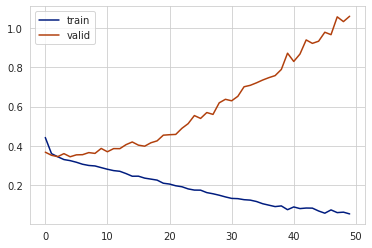

```python
plot_accuracy_forEPOCs(history1,model1,X_test,y_test)
```

This model is severely overfitting. Let us find the optimal point where the training should be stopped.

```
Best Threshold=0.021056, G-Mean=0.708
```

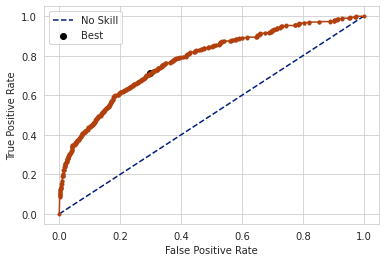

```python
plot_ROC_Curve(model1,X_test,y_test)
```

**Let's tune the threshold using ROC-AUC**

There are many ways we could locate the threshold with the optimal balance between false positive and true positive rates.

Firstly, the true positive rate is called the Sensitivity. The inverse of the false-positive rate is called the Specificity.

Sensitivity = True Positive / (True Positive + False Negative)

Specificity = True Negative / (False Positive + True Negative)

Where:

Sensitivity = True Positive Rate

Specificity = 1 – False Positive Rate

The Geometric Mean or G-Mean is a metric for imbalanced classification that, if optimized, will seek a balance between the sensitivity and the specificity.

G-Mean = sqrt(Sensitivity * Specificity)

One approach would be to test the model with each threshold returned from the call roc_auc_score(),

and select the threshold with the **largest G-Mean value.**

```python
#Predicting the results using best as a threshold
y_pred_e1 = model1.predict(X_test)
y_pred_e1 = (y_pred_e1 > globalThreshold[0])
y_pred_e1
```

```
array([[False],
       [False],
       [False],
       ...,
       [False],
       [False],
       [ True]])
```

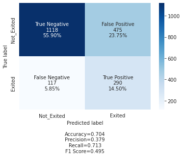

```python
create_confusionMatrix(y_test, y_pred_e1)
```

### Model 2_1 - Using RMSProp optimizer

```python
clear_backend()
```

```python
model2_1 = Sequential()
#Adding the hidden and output layers
model2_1.add(Dense(256,activation='relu',kernel_initializer='he_uniform',input_dim = X_train.shape[1]))
model2_1.add(Dense(128,activation='relu',kernel_initializer='he_uniform'))
model2_1.add(Dense(64,activation='relu',kernel_initializer='he_uniform'))
model2_1.add(Dense(32,activation='relu',kernel_initializer='he_uniform'))
model2_1.add(Dense(1, activation = 'sigmoid'))
#Compiling the ANN with RMSprop optimizer and binary cross entropy loss function
optimizer = tf.keras.optimizers.RMSprop(0.001)
model2_1.compile(loss='binary_crossentropy',optimizer=optimizer,metrics=['accuracy'])
```

```python
model2_1.summary()
```

```
Model: "sequential"
_________________________________________________________________
 Layer (type)                Output Shape              Param #
=================================================================
 dense (Dense)               (None, 256)               3328

 dense_1 (Dense)             (None, 128)               32896

 dense_2 (Dense)             (None, 64)                8256

 dense_3 (Dense)             (None, 32)                2080

 dense_4 (Dense)             (None, 1)                 33

=================================================================
Total params: 46,593
Trainable params: 46,593
Non-trainable params: 0
_________________________________________________________________
```

```python
history2_1 = model2_1.fit(X_train,y_train,batch_size=64,epochs=50,verbose=1,validation_split = 0.2)
```

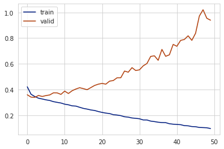

```python
plot_accuracy_forEPOCs(history2_1,model2_1,X_test,y_test)
```

This model is severely overfitting. Let us find the optimal point where the training should be stopped.

```
Best Threshold=0.029119, G-Mean=0.704
```

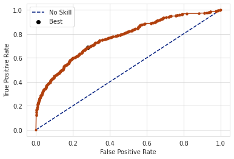

```python
plot_ROC_Curve(model2_1,X_test,y_test)
```

```python
#Predicting the results using best as a threshold
y_pred_e2_1=model1.predict(X_test)
y_pred_e2_1 = (y_pred_e2_1 > globalThreshold[0])
y_pred_e2_1
```

```
array([[False],
       [False],
       [False],
       ...,
       [False],
       [False],
       [ True]])
```

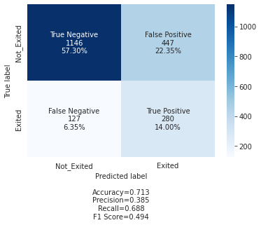

```python
#Calculating the confusion matrix
create_confusionMatrix(y_test, y_pred_e2_1)
```

```python
#Accuracy as per the classification report
cr2=metrics.classification_report(y_test,y_pred_e2_1)
print('Model using RMSProp optimizer and Threshold ' + str(globalThreshold[0]))
print(cr2)
```

[output not shown]

Now let's try to use the Batch Normalization technique and check to see if we can increase the recall.

### Model 3 - Using Batch Normalization

```python
clear_backend()
```

```python
model3 = Sequential()
model3.add(Dense(128,activation='relu',input_dim = X_train.shape[1]))
# model2.add(BatchNormalization())
model3.add(Dense(64,activation='relu',kernel_initializer='he_uniform'))
model3.add(BatchNormalization())
model3.add(Dense(32,activation='relu',kernel_initializer='he_uniform'))
model3.add(Dense(1, activation = 'sigmoid'))
```

```python
model3.summary()
```

```
Model: "sequential"
_________________________________________________________________
 Layer (type)                Output Shape              Param #
=================================================================
 dense (Dense)               (None, 128)               1664

 dense_1 (Dense)             (None, 64)                8256

 batch_normalization (BatchN  (None, 64)               256
 ormalization)

 dense_2 (Dense)             (None, 32)                2080

 dense_3 (Dense)             (None, 1)                 33

=================================================================
Total params: 12,289
Trainable params: 12,161
Non-trainable params: 128
_________________________________________________________________
```

```python
optimizer = tf.keras.optimizers.Adam(0.001)
model3.compile(loss='binary_crossentropy',optimizer=optimizer,metrics=['accuracy'])
```

```python
history_3 = model3.fit(X_train,y_train,batch_size=64,epochs=50,verbose=1,validation_split = 0.2)
```

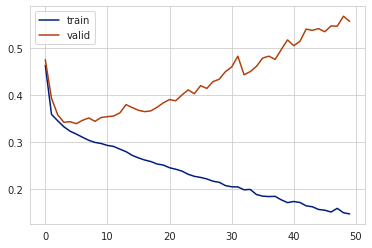

```python
plot_accuracy_forEPOCs(history_3,model3,X_test,y_test)
```

Unfortunately, from the above plot we observe that there is a lot of noise in the model, and it and seems to have overfitted on the training data.

```
Best Threshold=0.076360, G-Mean=0.740
```

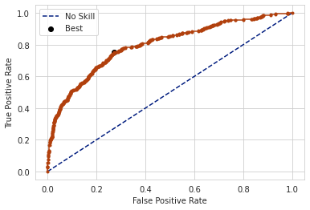

```python
plot_ROC_Curve(model3,X_test,y_test)
```

```python
y_pred_e3 = model3.predict(X_test)
y_pred_e3 = (y_pred_e3 > globalThreshold[0])
y_pred_e3
```

```
array([[False],
       [False],
       [False],
       ...,
       [ True],
       [False],
       [ True]])
```

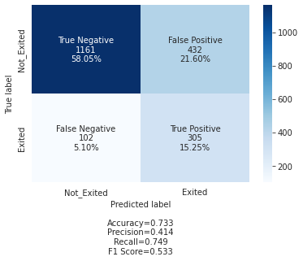

```python
#Calculating the confusion matrix
create_confusionMatrix(y_test, y_pred_e3)
```

```python
#Accuracy as per the classification report
cr3=metrics.classification_report(y_test,y_pred_e3)
print('Model using Batch Normalization and Threshold ' + str(globalThreshold[0]))
print(cr3)
```

```
Model using Batch Normalization and Threshold 0.076360196
              precision    recall  f1-score   support

           0       0.92      0.73      0.81      1593
           1       0.41      0.75      0.53       407

    accuracy                           0.73      2000
   macro avg       0.67      0.74      0.67      2000
weighted avg       0.82      0.73      0.76      2000
```

The Train and Validation curves seem to show overfitting despite having a good recall and a low False Negative rate.

Let's try to use the Dropout technique and check to see if it can reduce the False Negative rate.

### Model 4 - Using Dropout

```python
clear_backend()
```

```python
model4 = Sequential()
model4.add(Dense(256,activation='relu',input_dim = X_train.shape[1]))
model4.add(Dropout(0.2))
model4.add(Dense(128,activation='relu'))
model4.add(Dropout(0.2))
model4.add(Dense(64,activation='relu'))
model4.add(Dropout(0.2))
model4.add(Dense(32,activation='relu'))
model4.add(Dense(1, activation = 'sigmoid'))
```

```python
model4.summary()
```

```
Model: "sequential"
_________________________________________________________________
 Layer (type)                Output Shape              Param #
=================================================================
 dense (Dense)               (None, 256)               3328

 dropout (Dropout)           (None, 256)               0

 dense_1 (Dense)             (None, 128)               32896

 dropout_1 (Dropout)         (None, 128)               0

 dense_2 (Dense)             (None, 64)                8256

 dropout_2 (Dropout)         (None, 64)                0

 dense_3 (Dense)             (None, 32)                2080

 dense_4 (Dense)             (None, 1)                 33

=================================================================
Total params: 46,593
Trainable params: 46,593
Non-trainable params: 0
_________________________________________________________________
```

```python
optimizer = tf.keras.optimizers.Adam(0.001)
model4.compile(loss='binary_crossentropy',optimizer=optimizer,metrics=['accuracy'])
```

```python
history_4 = model4.fit(X_train,y_train,batch_size=64,epochs=50,verbose=1,validation_split = 0.2)
```

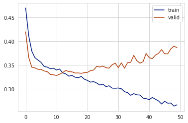

```python
plot_accuracy_forEPOCs(history_4,model,X_test,y_test)
```

There is a slight improvement in the model, but it is still overfitting and have noise.

```
Best Threshold=0.150759, G-Mean=0.753
```

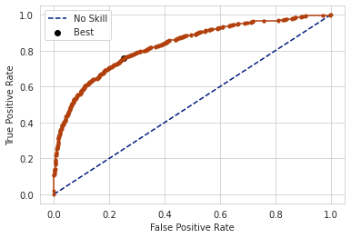

```python
plot_ROC_Curve(model4,X_test,y_test)
```

```python
y_pred_e4=model4.predict(X_test)
y_pred_e4 = (y_pred_e4 > globalThreshold[0])
y_pred_e4
```

```
array([[False],
       [False],
       [False],
       ...,
       [ True],
       [False],
       [ True]])
```

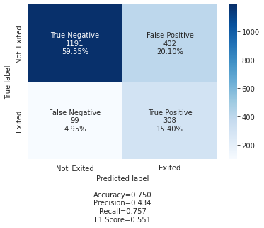

```python
#Calculating the confusion matrix
create_confusionMatrix(y_test, y_pred_e4)
```

```python
#Accuracy as per the classification report
cr4=metrics.classification_report(y_test,y_pred_e4)
print('Model using Dropout and Threshold ' + str(globalThreshold[0]))
print(cr4)
```

```
Model using Dropout and Threshold 0.15075871
              precision    recall  f1-score   support

           0       0.92      0.75      0.83      1593
           1       0.43      0.76      0.55       407

    accuracy                           0.75      2000
   macro avg       0.68      0.75      0.69      2000
weighted avg       0.82      0.75      0.77      2000
```

The Dropout technique helped the model reduce the loss function of both train and validation. The recall score also seems to be fine, with a decrease in the False Negative rate.

Now, let's try to use early stopping to see if we can increase the recall score of the model.

### Model 4_1 - Early Stopping

**Early stopping:**

During training, the model is evaluated on a holdout validation dataset after each epoch. If the performance of the model on the validation dataset starts to degrade or no improvement (e.g. loss begins to increase or accuracy begins to decrease), then the training process is stopped after the certian interations.The model at the time that training is stopped is then used and is known to have good generalization performance.

This procedure is called “early stopping” and is perhaps one of the oldest and most widely used forms of neural network regularization.

**Weight Initialization**

Weight initialization is an important consideration in the design of a neural network model.

The nodes in neural networks are composed of parameters referred to as weights used to calculate a weighted sum of the inputs.

Neural network models are fit using an optimization algorithm called stochastic gradient descent that incrementally changes the network weights to minimize a loss function, hopefully resulting in a set of weights for the mode that is capable of making useful predictions.

This optimization algorithm requires a starting point in the space of possible weight values from which to begin the optimization process. Weight initialization is a procedure to set the weights of a neural network to small random values that define the starting point for the optimization (learning or training) of the neural network model.

There are many WI techniques as follows:

1) Random normal initialization

2) Random Uniform initialization

3) Xaviour Initialization

4) He Initialization

```python
clear_backend()
```

```python
#Training Multi-layer perceptron with 2 hidden layers

#adding earlystopping callback
es= tf.keras.callbacks.EarlyStopping(monitor='val_loss',
                              min_delta=0,
                              patience=15,

                             verbose=1, mode='min', restore_best_weights= True)
Model4_1 = Sequential()
#Initializing the weights uisng hue_normal
Model4_1.add(Dense(65, input_dim = X_train.shape[1], kernel_initializer='he_normal', activation='relu'))
Model4_1.add(Dropout(0.5))
Model4_1.add(Dense(65, kernel_initializer='he_normal', activation='relu'))
Model4_1.add(Dropout(0.5))
Model4_1.add(Dense(1, kernel_initializer='he_normal', activation='sigmoid'))
optimizer = tf.keras.optimizers.Adam(0.001)
Model4_1.compile(optimizer, loss='binary_crossentropy', metrics=['accuracy'])

his_mod4_1= Model4_1.fit(X_train, y_train, validation_split=0.2, batch_size=700, epochs=40, callbacks=[es], shuffle=True, verbose=1)
```

Plotting the train and validation loss

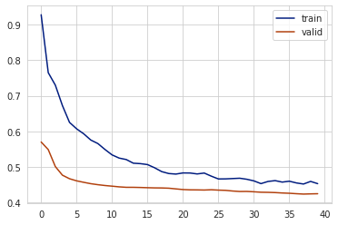

```python
plot_accuracy_forEPOCs(his_mod4_1,Model4_1,X_test,y_test)
```

Plotting confusion matrix

```python
y_pred_e4_1=Model4_1.predict(X_test)
y_pred_e4_1 = (y_pred_e4_1 > globalThreshold[0])
y_pred_e4_1
```

```
array([[False],
       [ True],
       [ True],
       ...,
       [ True],
       [False],
       [ True]])
```

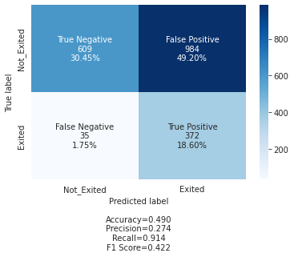

```python
create_confusionMatrix(y_test,y_pred_e4_1)
```

```python
#Accuracy as per the classification report
cr4_1 = metrics.classification_report(y_test,y_pred_e4_1)
print('Model using Early Stopping and Threshold ' + str(globalThreshold[0]))
print(cr4_1)
```

```
Model using Early Stopping and Threshold 0.15075871
              precision    recall  f1-score   support

           0       0.95      0.38      0.54      1593
           1       0.27      0.91      0.42       407

    accuracy                           0.49      2000
   macro avg       0.61      0.65      0.48      2000
weighted avg       0.81      0.49      0.52      2000
```

This model has a excellent recall score and the false negatives have gone down significantly. However the false positives have increased, so let us try some more techniques to fine tune the model.

Now, let's try to use some of the Hyperparameter Optimization techniques we have learnt, such as RandomizedSearchCV, GridSearchCV and Keras Tuner to increase the recall score of the model.

### Model 5 - Hyperparameter tuning using RandmizedSearchCV

#### **Random Search CV**

Some important hyperparameters to look out for while optimizing neural networks are:

- Type of Architecture
- Number of Layers
- Number of Neurons in a layer
- Regularization hyperparameters
- Learning Rate
- Type of Optimizer
- Dropout Rate

```python
clear_backend()
```

```python
def create_model_v4(lr,batch_size):
    np.random.seed(1337)
    model = Sequential()
    model.add(Dense(256,activation='relu',input_dim = X_train.shape[1]))
    model.add(Dropout(0.3))
    model.add(Dense(128,activation='relu'))
    model.add(Dropout(0.3))
    model.add(Dense(64,activation='relu'))
    model.add(Dropout(0.2))
    model.add(Dense(32,activation='relu'))
    model.add(Dense(1, activation='sigmoid'))

    #compile model
    optimizer = tf.keras.optimizers.Adam(learning_rate=lr)
    model.compile(optimizer = optimizer,loss = 'binary_crossentropy', metrics = ['accuracy'])
    return model
```

We are using Random search to optimize three hyperparameters - **Batch size, EPOCH** & **Learning Rate**.

You can also optimize other hyperparameters as mentioned above.

```python
keras_estimator = KerasClassifier(build_fn=create_model_v4, verbose=1)
# define the grid search parameters
param_random = {
    'batch_size':[32, 64, 128],
    'nb_epoch':[10,20,50],
    "lr":[0.01,0.1,0.001],}

kfold_splits = 3
random= RandomizedSearchCV(estimator=keras_estimator,
                    verbose=1,
                    cv=kfold_splits,
                    param_distributions=param_random,n_jobs=-1)
```

```python
random_result = random.fit(X_train, y_train,validation_split=0.2,verbose=1)

# Summarize results
print("Best: %f using %s" % (random_result.best_score_, random_result.best_params_))
means = random_result.cv_results_['mean_test_score']
stds = random_result.cv_results_['std_test_score']
params = random_result.cv_results_['params']
```

```
Fitting 3 folds for each of 10 candidates, totalling 30 fits
Best: 0.838751 using {'nb_epoch': 50, 'lr': 0.01, 'batch_size': 64}
```

The best model is with the following configuration:

( It may vary each time the code runs )

**Result of Random Search**

{'nb_epoch': 50, 'lr': 0.01, 'batch_size': 64}

Let's create the final model with the above mentioned configuration

```python
estimator_v4=create_model_v4(batch_size=random_result.best_params_['batch_size'],lr=random_result.best_params_['lr'])

estimator_v4.summary()
```

```
Model: "sequential_1"
_________________________________________________________________
 Layer (type)                Output Shape              Param #
=================================================================
 dense_5 (Dense)             (None, 256)               3328

 dropout_3 (Dropout)         (None, 256)               0

 dense_6 (Dense)             (None, 128)               32896

 dropout_4 (Dropout)         (None, 128)               0

 dense_7 (Dense)             (None, 64)                8256

 dropout_5 (Dropout)         (None, 64)                0

 dense_8 (Dense)             (None, 32)                2080

 dense_9 (Dense)             (None, 1)                 33

=================================================================
Total params: 46,593
Trainable params: 46,593
Non-trainable params: 0
_________________________________________________________________
```

```python
optimizer = tf.keras.optimizers.Adam(random_result.best_params_['lr'])
estimator_v4.compile(loss='binary_crossentropy',optimizer=optimizer,metrics=['accuracy'])
history_4=estimator_v4.fit(X_train, y_train, epochs=random_result.best_params_['nb_epoch'], batch_size = 64, verbose=1,validation_split=0.2)
```

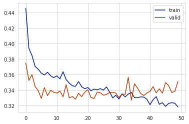

```python
plot_accuracy_forEPOCs(history_4,estimator_v4,X_test,y_test)
```

From the above plot, we observe that there is noise in the training behavior of the model.

```
Best Threshold=0.200597, G-Mean=0.770
```

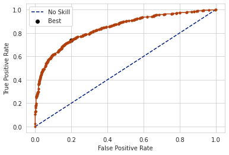

```python
plot_ROC_Curve(estimator_v4,X_test,y_test)
```

```python
y_pred_e4=estimator_v4.predict(X_test)
y_pred_e4 = (y_pred_e4 > globalThreshold[0])
y_pred_e4
```

```
array([[False],
       [False],
       [False],
       ...,
       [ True],
       [False],
       [False]])
```

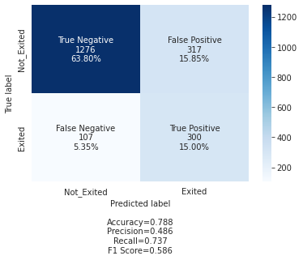

```python
#Calculating the confusion matrix
create_confusionMatrix(y_test, y_pred_e4)
```

```python
#Accuracy as per the classification report
cr5 = metrics.classification_report(y_test,y_pred_e4)
print('Model using Hyperparameter tuning and RandomizedSearchCV' + str(globalThreshold[0]))
print(cr5)
```

```
Model using Hyperparameter tuning and RandomizedSearchCV0.20059657
              precision    recall  f1-score   support

           0       0.92      0.80      0.86      1593
           1       0.49      0.74      0.59       407

    accuracy                           0.79      2000
   macro avg       0.70      0.77      0.72      2000
weighted avg       0.83      0.79      0.80      2000
```

Hyperparameter tuning is used here to get a better recall value, but the recall may differ each time.

Other hyperparameters can also be tuned to get better performance on the metrics.

Here, the recall of the model has decreased in comparison to the previous best performance, as Random Search CV will choose the hyperparameters randomly, and hence has a very low chance of finding a highly optimal configuration.

Let's use the more exhaustive Grid Search CV and see if the recall score increases.

### Model 6 - Hyperparameter tuning using GridSearchCV

#### **Grid Search CV**

Some important hyperparameters to look out for while optimizing neural networks are:

- Type of Architecture
- Number of Layers
- Number of Neurons in a layer
- Regularization hyperparameters
- Learning Rate
- Type of Optimizer
- Dropout Rate

```python
clear_backend()
```

```python
def create_model_v5(lr,batch_size):
    np.random.seed(1337)
    model = Sequential()
    model.add(Dense(256,activation='relu',input_dim = X_train.shape[1]))
    model.add(Dropout(0.3))
    model.add(Dense(128,activation='relu'))
    model.add(Dropout(0.3))
    model.add(Dense(64,activation='relu'))
    model.add(Dropout(0.2))
    model.add(Dense(32,activation='relu'))
    model.add(Dense(1, activation='sigmoid'))

    #compile model
    optimizer = tf.keras.optimizers.Adam(learning_rate=lr)
    model.compile(optimizer = optimizer,loss = 'binary_crossentropy', metrics = ['accuracy'])
    return model
```

We're using Grid Search to optimize three hyperparameters - **Batch Size, EPOCH** & **Learning Rate**.

You can also optimize the other hyperparameters as mentioned above.

```python
keras_estimator = KerasClassifier(build_fn=create_model_v5, verbose=1)
# define the grid search parameters
param_grid = {
    'batch_size':[64,32, 128],
    'nb_epoch':[10,20,50],
    "lr":[0.01,0.1,0.001]}

kfold_splits = 3
grid = GridSearchCV(estimator=keras_estimator,
                    verbose=1,
                    cv=kfold_splits,
                    param_grid=param_grid,n_jobs=-1)
```

```python
import time

# store starting time
begin = time.time()
grid_result = grid.fit(X_train, y_train,validation_split=0.2,verbose=1)

# Summarize results
print("Best: %f using %s" % (grid_result.best_score_, grid_result.best_params_))
means = grid_result.cv_results_['mean_test_score']
stds = grid_result.cv_results_['std_test_score']
params = grid_result.cv_results_['params']

time.sleep(1)
# store end time
end = time.time()

# total time taken
print(f"Total runtime of the program is {end - begin}")
```

```
Fitting 3 folds for each of 27 candidates, totalling 81 fits
Best: 0.838875 using {'batch_size': 64, 'lr': 0.01, 'nb_epoch': 20}
Total runtime of the program is 89.69241380691528
```

The best model has the following configuration:

( It may vary each time the code runs )

**Result of Grid Search**

{'batch_size': 64, 'lr': 0.01, 'nb_epoch': 20}

Let's create the final model with the above mentioned configuration

```python
estimator_v5=create_model_v5(batch_size=grid_result.best_params_['batch_size'],lr=grid_result.best_params_['lr'])

estimator_v5.summary()
```

```
Model: "sequential_1"
_________________________________________________________________
 Layer (type)                Output Shape              Param #
=================================================================
 dense_5 (Dense)             (None, 256)               3328

 dropout_3 (Dropout)         (None, 256)               0

 dense_6 (Dense)             (None, 128)               32896

 dropout_4 (Dropout)         (None, 128)               0

 dense_7 (Dense)             (None, 64)                8256

 dropout_5 (Dropout)         (None, 64)                0

 dense_8 (Dense)             (None, 32)                2080

 dense_9 (Dense)             (None, 1)                 33

=================================================================
Total params: 46,593
Trainable params: 46,593
Non-trainable params: 0
_________________________________________________________________
```

```python
optimizer = tf.keras.optimizers.Adam(grid_result.best_params_['lr'])
estimator_v5.compile(loss='binary_crossentropy',optimizer=optimizer,metrics=['accuracy'])
history_5=estimator_v5.fit(X_train, y_train, epochs=grid_result.best_params_['nb_epoch'], batch_size = grid_result.best_params_['batch_size'], verbose=1,validation_split=0.2)
```

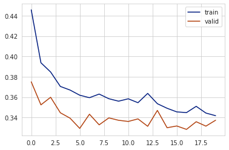

```python
plot_accuracy_forEPOCs(history_5,model,X_test,y_test)
```

From the above plot, we observe that both curves - train and validation, having noise.

```
Best Threshold=0.198826, G-Mean=0.778
```

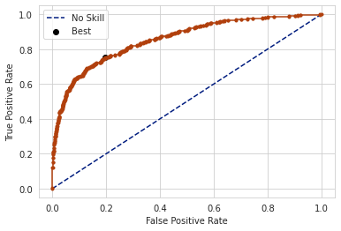

```python
plot_ROC_Curve(estimator_v5,X_test,y_test)
```

```python
y_pred_e5=estimator_v5.predict(X_test)
y_pred_e5 = (y_pred_e5 > globalThreshold[0])
y_pred_e5
```

```
array([[False],
       [False],
       [False],
       ...,
       [ True],
       [False],
       [False]])
```

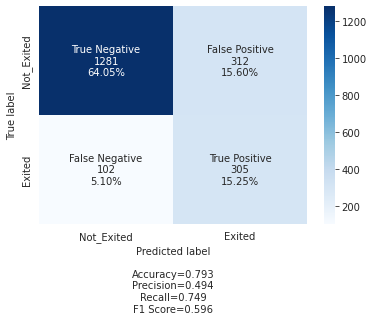

```python
#Calculating the confusion matrix
create_confusionMatrix(y_test, y_pred_e5)
```

```python
#Accuracy as per the classification report
cr6=metrics.classification_report(y_test,y_pred_e5)
print('Model using Hyperparameter tuning and GridSearchCV and Threshold' + str(globalThreshold[0]))
print(cr6)
```

```
Model using Hyperparameter tuning and GridSearchCV and Threshold0.19882604
              precision    recall  f1-score   support

           0       0.93      0.80      0.86      1593
           1       0.49      0.75      0.60       407

    accuracy                           0.79      2000
   macro avg       0.71      0.78      0.73      2000
weighted avg       0.84      0.79      0.81      2000
```

Hyperparameter tuning with Grid Search has been used here to get a recall score, but the recall score might differ each time.

Other hyperparameters can also be tuned to get better metrics.

### Dask

- There is also another library called Dask, sometimes used in the industry to provide a performance boost to Hyperparameter Tuning due to its parallelized computing procedure.
- Dask also has the option of implementing Grid Search similar to the Grid Search in Scikit-learn.

```python
# Try below code to install dask in Google Colab
!pip install dask-ml
```

```python
# importing library
from dask_ml.model_selection import GridSearchCV as DaskGridSearchCV
```

Try to run the code twice if you encounter any error while improting Dask

- Dask is the same as regular Grid Search in its functioning.
- We just have to change the function from GridSearchCV to DaskGridSearchCV.

```python
def create_model_v6(lr,batch_size):
    np.random.seed(1337)
    model = Sequential()
    model.add(Dense(256,activation='relu',input_dim = X_train.shape[1]))
    model.add(Dropout(0.3))
    model.add(Dense(128,activation='relu'))
    model.add(Dropout(0.3))
    model.add(Dense(64,activation='relu'))
    model.add(Dropout(0.2))
    model.add(Dense(32,activation='relu'))
    model.add(Dense(1, activation='sigmoid'))

    #compile model
    optimizer = tf.keras.optimizers.Adam(learning_rate=lr)
    model.compile(optimizer = optimizer,loss = 'binary_crossentropy', metrics = ['accuracy'])
    return model
```

```python
clear_backend()
```

```python
keras_estimator = KerasClassifier(build_fn=create_model_v6, verbose=1)
# define the grid search parameters
param_grid = {
    'batch_size':[64,32, 128],
    'nb_epoch':[10,20,50],
    "lr":[0.001,0.01,0.1],}

kfold_splits = 3
dask = DaskGridSearchCV(estimator=keras_estimator,
                    cv=kfold_splits,
                    param_grid=param_grid,n_jobs=-1)
```

```python
import time

# store starting time
begin = time.time()
dask_result = dask.fit(X_train, y_train,validation_split=0.2,verbose=1)

# Summarize results
print("Best: %f using %s" % (dask_result.best_score_, dask_result.best_params_))
means = dask_result.cv_results_['mean_test_score']
stds = dask_result.cv_results_['std_test_score']
params = dask_result.cv_results_['params']

time.sleep(1)
# store end time
end = time.time()

# total time taken
print(f"Total runtime of the program is {end - begin}")
```

```
Best: 0.835500 using {'batch_size': 64, 'lr': 0.01, 'nb_epoch': 50}
Total runtime of the program is 151.712256193161
```

Unfortunately, Dask took more time to run the model when compared to Grid Search CV, and this is because Dask has some requirements to perform well:

- The dimension of the dataset should be large.
- Dask shows a significant performance improvement in computation when the number and range of hyperparameters we are tuning is large.

Since the dataset dimensions and hyperparameter number/range were small for this example, Dask couldn't show a significant improvement.

We can also use another optimization technique - Keras Tuner.

```python
## Install Keras Tuner
!pip install keras-tuner
```

### Keras Tuner

```python
from tensorflow import keras
from tensorflow.keras import layers
from kerastuner.tuners import RandomSearch
```

```python
clear_backend()
```

**Hyperparameters**

- How many hidden layers should the model have?
- How many neurons should the model have in each hidden layer?
- Learning Rate

```python
def build_model(h):
    model = keras.Sequential()
    for i in range(h.Int('num_layers', 2, 10)):
        model.add(layers.Dense(units=h.Int('units_' + str(i),
                                            min_value=32,
                                            max_value=256,
                                            step=32),
                               activation='relu'))
    model.add(layers.Dense(1, activation='sigmoid'))
    model.compile(
        optimizer=keras.optimizers.Adam(
            h.Choice('learning_rate', [1e-2, 1e-3, 1e-4])),
        loss='binary_crossentropy',
        metrics=['accuracy'])
    return model
```

Initialize a tuner (here, RandomSearch). We use objective to specify the objective to select the best models, and we use max_trials to specify the number of different models to try.

```python
tuner = RandomSearch(
    build_model,
    objective='val_accuracy',
    max_trials=5,
    executions_per_trial=3,
     project_name='Job_')
```

```
INFO:tensorflow:Reloading Oracle from existing project ./Job_/oracle.json
INFO:tensorflow:Reloading Tuner from ./Job_/tuner0.json
```

```python
tuner.search_space_summary()
```

```
Search space summary
Default search space size: 11
num_layers (Int)
{'default': None, 'conditions': [], 'min_value': 2, 'max_value': 10, 'step': 1, 'sampling': None}
units_0 (Int)
{'default': None, 'conditions': [], 'min_value': 32, 'max_value': 256, 'step': 32, 'sampling': None}
units_1 (Int)
{'default': None, 'conditions': [], 'min_value': 32, 'max_value': 256, 'step': 32, 'sampling': None}
learning_rate (Choice)
{'default': 0.01, 'conditions': [], 'values': [0.01, 0.001, 0.0001], 'ordered': True}
units_2 (Int)
{'default': None, 'conditions': [], 'min_value': 32, 'max_value': 256, 'step': 32, 'sampling': None}
units_3 (Int)
{'default': None, 'conditions': [], 'min_value': 32, 'max_value': 256, 'step': 32, 'sampling': None}
units_4 (Int)
{'default': None, 'conditions': [], 'min_value': 32, 'max_value': 256, 'step': 32, 'sampling': None}
units_5 (Int)
{'default': None, 'conditions': [], 'min_value': 32, 'max_value': 256, 'step': 32, 'sampling': None}
units_6 (Int)
{'default': None, 'conditions': [], 'min_value': 32, 'max_value': 256, 'step': 32, 'sampling': None}
units_7 (Int)
{'default': None, 'conditions': [], 'min_value': 32, 'max_value': 256, 'step': 32, 'sampling': None}
units_8 (Int)
{'default': None, 'conditions': [], 'min_value': 32, 'max_value': 256, 'step': 32, 'sampling': None}
```

```python
### Searching the best model on X and y train
tuner.search(X_train, y_train,
             epochs=5,
             validation_split = 0.2)
```

```
INFO:tensorflow:Oracle triggered exit
```

```python
## Printing the best models with their hyperparameters
tuner.results_summary()
```

```
Results summary
Results in ./Job_
Showing 10 best trials
<keras_tuner.engine.objective.Objective object at 0x7f77c5630610>
Trial summary
Hyperparameters:
num_layers: 8
units_0: 160
units_1: 64
learning_rate: 0.001
units_2: 160
units_3: 64
units_4: 192
units_5: 32
units_6: 224
units_7: 96
units_8: 192
Score: 0.8733333150545756
Trial summary
Hyperparameters:
num_layers: 5
units_0: 160
units_1: 160
learning_rate: 0.001
units_2: 224
units_3: 128
units_4: 224
units_5: 64
units_6: 160
units_7: 64
units_8: 32
Score: 0.8697916666666666
Trial summary
Hyperparameters:
num_layers: 5
units_0: 64
units_1: 96
learning_rate: 0.001
units_2: 96
units_3: 224
```

[output cut: 19 more lines]

```
Score: 0.8606250087420145
Trial summary
Hyperparameters:
num_layers: 9
units_0: 192
units_1: 96
learning_rate: 0.0001
units_2: 32
units_3: 32
units_4: 32
units_5: 32
units_6: 32
units_7: 32
units_8: 32
Score: 0.8579166730244955
```

### Model 7

```python
clear_backend()
```

```python
model7 = Sequential()
model7.add(Dense(160,activation='relu',kernel_initializer='he_uniform',input_dim = X_train.shape[1]))
model7.add(Dense(160,activation='relu',kernel_initializer='he_uniform'))
model7.add(Dense(224,activation='relu',kernel_initializer='he_uniform'))
model7.add(Dense(128,activation='relu',kernel_initializer='he_uniform'))
model7.add(Dense(224,activation='relu',kernel_initializer='he_uniform'))
model7.add(Dense(1, activation = 'sigmoid'))
```

```python
model7.summary()
```

```
Model: "sequential"
_________________________________________________________________
 Layer (type)                Output Shape              Param #
=================================================================
 dense (Dense)               (None, 160)               2080

 dense_1 (Dense)             (None, 160)               25760

 dense_2 (Dense)             (None, 224)               36064

 dense_3 (Dense)             (None, 128)               28800

 dense_4 (Dense)             (None, 224)               28896

 dense_5 (Dense)             (None, 1)                 225

=================================================================
Total params: 121,825
Trainable params: 121,825
Non-trainable params: 0
_________________________________________________________________
```

```python
optimizer = tf.keras.optimizers.Adam(0.001)
model7.compile(loss='binary_crossentropy',optimizer=optimizer,metrics=['accuracy'])
```

```python
history_7 = model7.fit(X_train,y_train,batch_size=64,epochs=50,verbose=1,validation_split = 0.2)
```

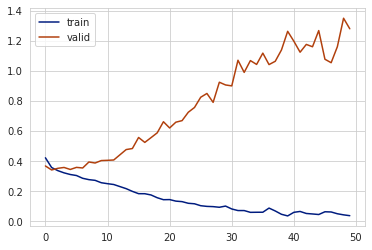

```python
plot_accuracy_forEPOCs(history_7,model,X_test,y_test)
```

From the above plot, we observe that the train and validation data are still overfitting and contain noise.

```
Best Threshold=0.005276, G-Mean=0.707
```

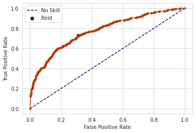

```python
plot_ROC_Curve(model7,X_test,y_test)
```

```python
y_pred_e7=model7.predict(X_test)
y_pred_e7 = (y_pred_e7 > globalThreshold[0])
y_pred_e7
```

```
array([[False],
       [False],
       [False],
       ...,
       [ True],
       [False],
       [ True]])
```

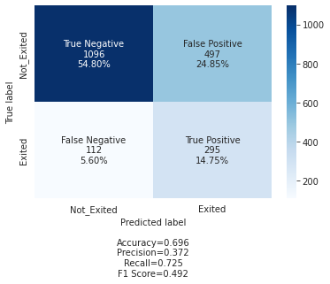

```python
#Calculating the confusion matrix
create_confusionMatrix(y_test, y_pred_e7)
```

```python
#Accuracy as per the classification report
cr7=metrics.classification_report(y_test,y_pred_e7)
print('Final Model using the best Hyperparameters')
print(cr7)
```

[output not shown]

### SMOTE + Keras Tuner

```python
##Applying SMOTE on train and test
from imblearn.over_sampling import SMOTE
smote=SMOTE(sampling_strategy='not majority')
X_sm , y_sm = smote.fit_resample(X_train,y_train)
```

```python
clear_backend()
```

```python
def build_model_2(h):
    model = keras.Sequential()
    for i in range(h.Int('num_layers', 2, 10)):
        model.add(layers.Dense(units=h.Int('units_' + str(i),
                                            min_value=32,
                                            max_value=256,
                                            step=32),
                               activation='relu'))
    model.add(layers.Dense(1, activation='sigmoid'))
    model.compile(
        optimizer=keras.optimizers.Adam(
            h.Choice('learning_rate', [1e-2, 1e-3, 1e-4])),
        loss='binary_crossentropy',
        metrics=['accuracy'])
    return model
```

```python
tuner_2 = RandomSearch(
    build_model_2,
    objective='val_accuracy',
    max_trials=5,
    executions_per_trial=3,
    project_name='Churn_Prediction')
```

```
INFO:tensorflow:Reloading Oracle from existing project ./Churn_Prediction/oracle.json
INFO:tensorflow:Reloading Tuner from ./Churn_Prediction/tuner0.json
```

```python
tuner_2.search_space_summary()
```

```
Search space summary
Default search space size: 11
num_layers (Int)
{'default': None, 'conditions': [], 'min_value': 2, 'max_value': 10, 'step': 1, 'sampling': None}
units_0 (Int)
{'default': None, 'conditions': [], 'min_value': 32, 'max_value': 256, 'step': 32, 'sampling': None}
units_1 (Int)
{'default': None, 'conditions': [], 'min_value': 32, 'max_value': 256, 'step': 32, 'sampling': None}
learning_rate (Choice)
{'default': 0.01, 'conditions': [], 'values': [0.01, 0.001, 0.0001], 'ordered': True}
units_2 (Int)
{'default': None, 'conditions': [], 'min_value': 32, 'max_value': 256, 'step': 32, 'sampling': None}
units_3 (Int)
{'default': None, 'conditions': [], 'min_value': 32, 'max_value': 256, 'step': 32, 'sampling': None}
units_4 (Int)
{'default': None, 'conditions': [], 'min_value': 32, 'max_value': 256, 'step': 32, 'sampling': None}
units_5 (Int)
{'default': None, 'conditions': [], 'min_value': 32, 'max_value': 256, 'step': 32, 'sampling': None}
units_6 (Int)
{'default': None, 'conditions': [], 'min_value': 32, 'max_value': 256, 'step': 32, 'sampling': None}
units_7 (Int)
{'default': None, 'conditions': [], 'min_value': 32, 'max_value': 256, 'step': 32, 'sampling': None}
units_8 (Int)
{'default': None, 'conditions': [], 'min_value': 32, 'max_value': 256, 'step': 32, 'sampling': None}
```

```python
tuner_2.search(X_sm, y_sm,
             epochs=5,
             validation_split = 0.2)
```

```
INFO:tensorflow:Oracle triggered exit
```

```python
tuner_2.results_summary()
```

```
Results summary
Results in ./Churn_Prediction
Showing 10 best trials
<keras_tuner.engine.objective.Objective object at 0x7f77c50f76d0>
Trial summary
Hyperparameters:
num_layers: 8
units_0: 160
units_1: 64
learning_rate: 0.001
units_2: 160
units_3: 64
units_4: 192
units_5: 32
units_6: 224
units_7: 96
units_8: 192
Score: 0.8104395667711893
Trial summary
Hyperparameters:
num_layers: 5
units_0: 160
units_1: 160
learning_rate: 0.001
units_2: 224
units_3: 128
units_4: 224
units_5: 64
units_6: 160
units_7: 64
units_8: 32
Score: 0.7980115016301473
Trial summary
Hyperparameters:
num_layers: 5
units_0: 64
units_1: 96
learning_rate: 0.001
units_2: 96
units_3: 224
```

[output cut: 19 more lines]

```
Score: 0.7167713046073914
Trial summary
Hyperparameters:
num_layers: 9
units_0: 128
units_1: 32
learning_rate: 0.0001
units_2: 160
units_3: 160
units_4: 160
units_5: 192
units_6: 96
units_7: 128
units_8: 96
Score: 0.7095761299133301
```

```python
clear_backend()
```

```python
model9 = Sequential()
model9.add(Dense(160,activation='relu',kernel_initializer='he_uniform',input_dim = X_train.shape[1]))
model9.add(Dense(160,activation='relu',kernel_initializer='he_uniform'))
model9.add(Dense(224,activation='relu',kernel_initializer='he_uniform'))
model9.add(Dense(128,activation='relu',kernel_initializer='he_uniform'))
model9.add(Dense(224,activation='relu',kernel_initializer='he_uniform'))
model9.add(Dense(1, activation = 'sigmoid'))
      #Compiling the ANN with Adam optimizer and binary cross entropy loss function
optimizer = tf.keras.optimizers.Adam(0.001)
model9.compile(loss='binary_crossentropy',optimizer=optimizer,metrics=['accuracy'])
```

```python
model9.summary()
```

```
Model: "sequential"
_________________________________________________________________
 Layer (type)                Output Shape              Param #
=================================================================
 dense (Dense)               (None, 160)               2080

 dense_1 (Dense)             (None, 160)               25760

 dense_2 (Dense)             (None, 224)               36064

 dense_3 (Dense)             (None, 128)               28800

 dense_4 (Dense)             (None, 224)               28896

 dense_5 (Dense)             (None, 1)                 225

=================================================================
Total params: 121,825
Trainable params: 121,825
Non-trainable params: 0
_________________________________________________________________
```

```python
history_9 = model9.fit(X_sm,y_sm,batch_size=64,epochs=50,verbose=1,validation_split = 0.2)
```

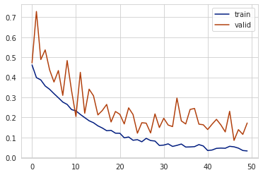

```python
plot_accuracy_forEPOCs(history_9,model,X_test,y_test)
```

From the above plot, we observe that there is a lot of noise in the model.

```
Best Threshold=0.001233, G-Mean=0.729
```

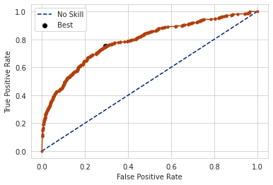

```python
plot_ROC_Curve(model9,X_test,y_test)
```

```python
y_pred_e9=model9.predict(X_test)
y_pred_e9 = (y_pred_e9 > globalThreshold[0])
y_pred_e9
```

```
array([[False],
       [False],
       [False],
       ...,
       [ True],
       [False],
       [ True]])
```

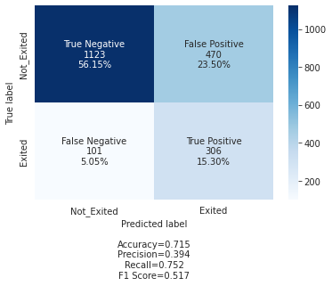

```python
#Calculating the confusion matrix
create_confusionMatrix(y_test, y_pred_e9)
```

```python
#Accuracy as per the classification report
from sklearn import metrics
cr8=metrics.classification_report(y_test,y_pred_e9)
print('Final Model using SMOTE + Keras')
print(cr8)
```

```
Final Model using SMOTE + Keras
              precision    recall  f1-score   support

           0       0.92      0.70      0.80      1593
           1       0.39      0.75      0.52       407

    accuracy                           0.71      2000
   macro avg       0.66      0.73      0.66      2000
weighted avg       0.81      0.71      0.74      2000
```

After applying the SMOTE technique to the data, the recall score increased, and the False Negative rate decreased, but if you see the loss curves of train and validation, the model seems to have overfit.

Let's use Grid Search CV and see if we can increase the model's performance on the metrics.

```python
clear_backend()
```

```python
def create_model_v7(lr,batch_size):
    np.random.seed(1337)
    model = Sequential()
    model.add(Dense(256,activation='relu',input_dim = X_train.shape[1]))
    model.add(Dropout(0.3))
    model.add(Dense(128,activation='relu'))
    model.add(Dropout(0.3))
    model.add(Dense(64,activation='relu'))
    model.add(Dropout(0.2))
    model.add(Dense(32,activation='relu'))
    model.add(Dense(1, activation='sigmoid'))

    #compile model
    optimizer = tf.keras.optimizers.Adam(learning_rate=lr)
    model.compile(optimizer = optimizer,loss = 'binary_crossentropy', metrics = ['accuracy'])
    return model
```

```python
keras_estimator = KerasClassifier(build_fn=create_model_v7, verbose=1)
```

```python
# define the grid search parameters
param_grid = {
    'batch_size':[32, 64, 128],
    'nb_epoch':[10,20,50],
    "lr":[0.001,0.01,0.1],}

kfold_splits = 3
grid = GridSearchCV(estimator=keras_estimator,
                    verbose=1,
                    cv=kfold_splits,
                    param_grid=param_grid,n_jobs=-1)
grid_result = grid.fit(X_train, y_train,validation_split=0.2,verbose=1)
```

```
Fitting 3 folds for each of 27 candidates, totalling 81 fits
```

```python
# Summarize results
print("Best: %f using %s" % (grid_result.best_score_, grid_result.best_params_))
means = grid_result.cv_results_['mean_test_score']
stds = grid_result.cv_results_['std_test_score']
params = grid_result.cv_results_['params']
```

```
Best: 0.839626 using {'batch_size': 32, 'lr': 0.01, 'nb_epoch': 10}
```

```python
estimator_v7=create_model_v7(batch_size=grid_result.best_params_['batch_size'],lr=grid_result.best_params_['lr'])

estimator_v7.summary()
```

```
Model: "sequential_1"
_________________________________________________________________
 Layer (type)                Output Shape              Param #
=================================================================
 dense_5 (Dense)             (None, 256)               3328

 dropout_3 (Dropout)         (None, 256)               0

 dense_6 (Dense)             (None, 128)               32896

 dropout_4 (Dropout)         (None, 128)               0

 dense_7 (Dense)             (None, 64)                8256

 dropout_5 (Dropout)         (None, 64)                0

 dense_8 (Dense)             (None, 32)                2080

 dense_9 (Dense)             (None, 1)                 33

=================================================================
Total params: 46,593
Trainable params: 46,593
Non-trainable params: 0
_________________________________________________________________
```

```python
optimizer = tf.keras.optimizers.Adam(grid_result.best_params_['lr'])
estimator_v7.compile(loss='binary_crossentropy',optimizer=optimizer,metrics=['accuracy'])
history_7=estimator_v7.fit(X_sm, y_sm, epochs=grid_result.best_params_['nb_epoch'], batch_size = grid_result.best_params_['batch_size'], verbose=1,validation_split=0.2)
```

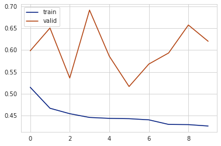

```python
plot_accuracy_forEPOCs(history_7,model,X_test,y_test)
```

From the above plot, we observe that there is a lot of noise in the model.

```
Best Threshold=0.316980, G-Mean=0.770
```

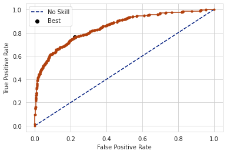

```python
plot_ROC_Curve(estimator_v7,X_test,y_test)
```

```python
y_pred_e10=estimator_v7.predict(X_test)
y_pred_e10 = (y_pred_e10 > globalThreshold[0])
y_pred_e10
```

```
array([[False],
       [False],
       [False],
       ...,
       [ True],
       [False],
       [False]])
```

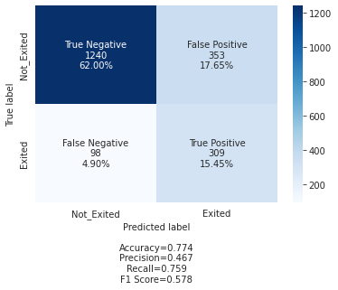

```python
#Calculating the confusion matrix
create_confusionMatrix(y_test, y_pred_e10)
```

```python
#Accuracy as per the classification report
from sklearn import metrics
cr10=metrics.classification_report(y_test,y_pred_e10)
print('Final Model using GridSearchCV')
print(cr10)
```

```
Final Model using GridSearchCV
              precision    recall  f1-score   support

           0       0.93      0.78      0.85      1593
           1       0.47      0.76      0.58       407

    accuracy                           0.77      2000
   macro avg       0.70      0.77      0.71      2000
weighted avg       0.83      0.77      0.79      2000
```

Oversampling using SMOTE did help improve the recall score.

In this dataset, the SMOTE oversampling technique does not work well, as both the models we tried building have overfitted on the training dataset.

So, our final model here can be **Model 4**, which uses the Dropout regularization technique and works on the imbalanced dataset.

### Scope of Improvement

- Build one Machine Learning model, preferably Model 4, and use that to get the feature importance of the variables. Try to use that in the neural network model.
- Other Models model3, model5 and model using SMOTE and Keras gave similar recall results, we can also pick one of those and try to reduce overfitting and noise.
- We can try to do better feature engineerning by removing the flaws of the skewed variables if required.

### Conclusion and Key Take aways - Business Recommendations

- Customers who have purchased more products and had a longer tenure seem to have exited more.
- Cutomers who had been with the bank for 2 years, seem to have purchased more products.
- Customers who have been with the bank for 4 to 10 years have purchased same number of products with a slight variation with customers with 5 year tenure.
- Around 500 customers who have a 0 balance have exited the bank.
- Less than 500 Customers in each range, who have balance between 50000 and 180000 have exited the bank.
- Majority of customers with the bank who have not exited and maintain a balance between 50,000 and 200,000.
- Custmers who are above 42 years of age and have a tenure between 0 and 10 have exited more.
- Customers who are in the the age group between 37 and 39 and have a tenure between 0 and 10 have exited more.
- Customers who have salary in the range between 98K and 100K have purchased 1 or 2 products.
- Customers who have salary in the range between 100K and 120K have purchased more 3 or 4 products.
- Customers who have not exited the bank have estimated salary in the range 98K and 100K.
- Customers who have exited the bank are in a higher estimated salary range of more than 100K.
- There are more customers from France compared to Spain and Germany.
- Customers from France and Germany exited more than the customers from France.
- Customers who have exited have a better credit score and a slightly longer tenure than the customers who have not exited.

Business Recomendation:

- Customers with higher income and female customers are leaving more, bank should focus on retaining these customers by offring special discouns or promotions to them. Sending out a survery to find out the reason for leaving might also help.
- There are more customers from France, when compare to Spain and Germany, Bank should work on ways to continue keeping this customers happy and making them more engaged and keeping them active in the Bank.
- Inspite of higher credit score and purchasing more products customers are leaving, bank should focus on bringing back these customers and mitigate ways to retain the customers in this segment.